# Wine Quality "Warm up" Challenge

## GROUP 12

*Arnaud Barral*

*Jeanne Barthélemy*

*Alice Dumay*

*Maxime Bouthors*

```python
import numpy as np # linear algebra
import pandas as pd # data processing, CSV file I/O (e.g. pd.read_csv)
import seaborn as sns
import matplotlib.pyplot as plt
from sklearn import preprocessing
from sklearn import svm
from sklearn.pipeline import Pipeline
from sklearn.ensemble import RandomForestRegressor, GradientBoostingRegressor, RandomForestClassifier
from sklearn.linear_model import LogisticRegression, LinearRegression
from sklearn.neighbors import KNeighborsClassifier
from sklearn.svm import SVR, SVC
from sklearn.metrics import confusion_matrix, accuracy_score
from sklearn.model_selection import cross_val_predict, train_test_split, GridSearchCV
```

```python
red = pd.read_csv("winequality-red.csv", sep=';')
white = pd.read_csv("winequality-white.csv", sep=';')

print("Import complete")
```

```
Import complete
```

### 1. Data preparation

#### Data exploration

```python
red.describe() # to have some statistics
```

|  | fixed acidity | volatile acidity | citric acid | residual sugar | chlorides | free sulfur dioxide | total sulfur dioxide | density | pH | sulphates | alcohol | quality |
| --- | --- | --- | --- | --- | --- | --- | --- | --- | --- | --- | --- | --- |
| count | 1599.000000 | 1599.000000 | 1599.000000 | 1599.000000 | 1599.000000 | 1599.000000 | 1599.000000 | 1599.000000 | 1599.000000 | 1599.000000 | 1599.000000 | 1599.000000 |
| mean | 8.319637 | 0.527821 | 0.270976 | 2.538806 | 0.087467 | 15.874922 | 46.467792 | 0.996747 | 3.311113 | 0.658149 | 10.422983 | 5.636023 |
| std | 1.741096 | 0.179060 | 0.194801 | 1.409928 | 0.047065 | 10.460157 | 32.895324 | 0.001887 | 0.154386 | 0.169507 | 1.065668 | 0.807569 |
| min | 4.600000 | 0.120000 | 0.000000 | 0.900000 | 0.012000 | 1.000000 | 6.000000 | 0.990070 | 2.740000 | 0.330000 | 8.400000 | 3.000000 |
| 25% | 7.100000 | 0.390000 | 0.090000 | 1.900000 | 0.070000 | 7.000000 | 22.000000 | 0.995600 | 3.210000 | 0.550000 | 9.500000 | 5.000000 |
| 50% | 7.900000 | 0.520000 | 0.260000 | 2.200000 | 0.079000 | 14.000000 | 38.000000 | 0.996750 | 3.310000 | 0.620000 | 10.200000 | 6.000000 |
| 75% | 9.200000 | 0.640000 | 0.420000 | 2.600000 | 0.090000 | 21.000000 | 62.000000 | 0.997835 | 3.400000 | 0.730000 | 11.100000 | 6.000000 |
| max | 15.900000 | 1.580000 | 1.000000 | 15.500000 | 0.611000 | 72.000000 | 289.000000 | 1.003690 | 4.010000 | 2.000000 | 14.900000 | 8.000000 |

```python
red.info() # features = float64 ; quality = int64
```

```
<class 'pandas.core.frame.DataFrame'>
RangeIndex: 1599 entries, 0 to 1598
Data columns (total 12 columns):
 #   Column                Non-Null Count  Dtype
---  ------                --------------  -----
 0   fixed acidity         1599 non-null   float64
 1   volatile acidity      1599 non-null   float64
 2   citric acid           1599 non-null   float64
 3   residual sugar        1599 non-null   float64
 4   chlorides             1599 non-null   float64
 5   free sulfur dioxide   1599 non-null   float64
 6   total sulfur dioxide  1599 non-null   float64
 7   density               1599 non-null   float64
 8   pH                    1599 non-null   float64
 9   sulphates             1599 non-null   float64
 10  alcohol               1599 non-null   float64
 11  quality               1599 non-null   int64
dtypes: float64(11), int64(1)
memory usage: 150.0 KB
```

```python
red.corr()["quality"].drop(["quality"]).abs() # detect correlation
```

```
fixed acidity           0.124052
volatile acidity        0.390558
citric acid             0.226373
residual sugar          0.013732
chlorides               0.128907
free sulfur dioxide     0.050656
total sulfur dioxide    0.185100
density                 0.174919
pH                      0.057731
sulphates               0.251397
alcohol                 0.476166
Name: quality, dtype: float64
```

> **Note**: Showing the same information about white wine would be redundant since the data are quite similar. The values in the features only seem shifted. The white wine dataset is also about 3 times bigger.

#### Data preprocessing

The dataset has already exploitable values with no missing information, for instance. It's seems there is no need also to make relevant feature combinations: the various features seem completely independant. So all we did was **normalizing** the data with scaling. This step is only useful for models sensitive to scaling, like KNN.

> **Note**: we do not change the format of the labels, keeping integer values between **1** and **10**. We will see that it is necessary if we consider the problem as a regresion task. Also it is not penalizing if we consider it as a classification task on the other hand.

```python
# Let's normalize

r = red.values #returns a numpy array
min_max_scaler = preprocessing.MinMaxScaler()
r_scaled = min_max_scaler.fit_transform(r) # scaling
red_normalized = pd.DataFrame(r_scaled, columns=red.columns, index=red.index) # new dataframe

w = white.values #returns a numpy array
min_max_scaler = preprocessing.MinMaxScaler()
w_scaled = min_max_scaler.fit_transform(w) # scaling
white_normalized = pd.DataFrame(w_scaled, columns=white.columns, index=white.index) # new dataframe
```

```python
# Separating features from labels

red_y = red['quality']
red_X = red_normalized.drop(['quality'], axis=1)

white_y = white['quality']
white_X = white_normalized.drop(['quality'], axis=1)
```

### 2. Model selection

We first chose to use reggresion models since this plot seems to indicate a gradient in the quality that seems even almost linear (quality accroding to volatile acidity and alcohol):

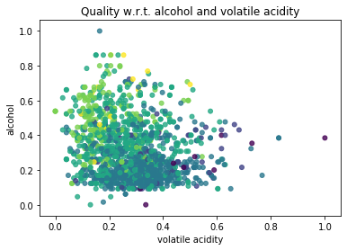

```python
# Features n°1 and n°10 are the most correlated with quality
plt.scatter(red_X.to_numpy()[:, 1], red_X.to_numpy()[:, 10], marker='o', c=red_y, s=25, alpha=0.8)
plt.xlabel("volatile acidity")
plt.ylabel("alcohol")
plt.title("Quality w.r.t. alcohol and volatile acidity")
plt.show()
```

This is why, even though it seems to be a classfication problem, regressive models can nonetheless be relevant. This plot can also justify the choice of KNN since there are areas with predominances of certain quality level.

```python
# Separation of test set and training set
Xr_train, Xr_test, yr_train, yr_test = train_test_split(red_X, red_y, test_size=0.2, random_state=0)
Xw_train, Xw_test, yw_train, yw_test = train_test_split(white_X, white_y, test_size=0.2, random_state=0)
```

Since the *ma*e or *mse* scoring is not relevant to compare classifiers and regressors, we chose to cross-validate on the predictive performances of each model. This means that we look at the *cross-validation accuracy* for the model selection.

The last plot above make us think that a simple **linear regression** would not have bad results since we have somehow a smooth gradient of the quality over some features (corresponding to the color gradient in the plotted figure).

A **linear regression** model will thus be a starting point that can then be used to evaluate the performance of the other more complex models we will use after.

### Regressive models

- With **linear regression**, we obtained a *cross-validation accuracy* of **0.58**.
- With **SVM regressor**, we obtained **0.61**. We chose to try SVM since it is generally a performant model in general cases. But here, we found out that, with its default parameters, it performed just slightly better than the linear regression.
- With **Random forest regressor**, we obtained **0.65**. We chose to test a random forest because this model usually performs well in such machine learning tasks (Kaggle competitions). Here, it performs rather well compared to the linear regression, even though this accuracy is not that extraordinary. Nonetheless, our guess is that the underlying distribution data is so noisy that achieving way better accuracies is impossible.

```python
### RANDOM FOREST
model = RandomForestRegressor(verbose = 0)

# With cross walidation scores, we have a better estimation of the efficiency of the model
ypred = np.around(cross_val_predict(model, Xr_train, yr_train.ravel(), cv=5)).astype(np.int64)
print("cross validation accuracy =", accuracy_score(yr_train.ravel(), ypred))
print("confusion matrix =\n", confusion_matrix(yr_train.ravel(), np.around(ypred).astype(np.int64)))
```

```
cross validation accuracy = 0.6450351837372947
confusion matrix =
 [[  0   3   4   1   0   0]
 [  0   3  28  10   1   0]
 [  0   2 411 129   4   0]
 [  0   0 126 337  33   0]
 [  0   0   5  93  74   0]
 [  0   0   0   6   9   0]]
```

We can see from the confusion matrix that there is a lot of confusion with the values of the quality 5 and 6. This comfort the idea that the distribution of the classes are quite mixed together.

### Classification models

Maybe, regressive models are not as relevant as we first thought, so we tried to see the performances of classification models.

- **KNN** may be a relevant classifier, though "expensive" in terms of prediction computing. We also need to estimate the right "k", the number of neighbors taken into account since it is the only important tunable parameter, and it si easy to see where is the best "k" by plotting the cross validation accuracy for a given range of values.

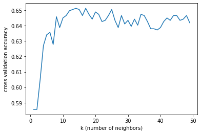

```python
n_neighbors = np.arange(1, 50, 1)
accs = []
for n_neighbor in n_neighbors:
    model = KNeighborsClassifier(n_neighbors=n_neighbor, weights='distance')
    ypred = cross_val_predict(model, Xr_train, yr_train.ravel(), cv=4)
    accs.append(accuracy_score(ypred, yr_train))
plt.plot(n_neighbors, accs)
plt.xlabel("k (number of neighbors)")
plt.ylabel("cross validation accuracy")
plt.show()
```

We see that *k* is optimal around **15** with a cross validation accuracy of **0.65**.

```python
### Random forest classification
model = RandomForestClassifier(n_estimators=10) # default value

# With cross walidation scores, we have a better estimation of the efficiency of the model
ypred = cross_val_predict(model, Xr_train, yr_train.ravel(), cv=5)
print("cross validation accuracy =", accuracy_score(yr_train.ravel(), ypred))
```

```
cross validation accuracy = 0.63721657544957
```

### Hyperparameter tuning

To optimize our forest model, we'll use grid search.

```python
model =  RandomForestClassifier(verbose=0)
model.get_params().keys()
```

```
dict_keys(['bootstrap', 'class_weight', 'criterion', 'max_depth', 'max_features', 'max_leaf_nodes', 'min_impurity_decrease', 'min_impurity_split', 'min_samples_leaf', 'min_samples_split', 'min_weight_fraction_leaf', 'n_estimators', 'n_jobs', 'oob_score', 'random_state', 'verbose', 'warm_start'])
```

- **Red wine**

```python
parameters = {
    "n_estimators":[50],
    "min_samples_split": np.linspace(0.001, 0.005, 5),
    "min_samples_leaf": np.linspace(0.0005, 0.005, 5),
    "max_depth":[20, 15, 10],
    "max_features":["auto", "log2", "sqrt"],
    "criterion": ["gini",  "entropy"],
    }

grid_search = GridSearchCV(model, parameters, verbose = 1, n_jobs=-1, cv=5)

grid_search.fit(Xr_train, yr_train.values.ravel())
print(grid_search.best_score_)
print(grid_search.best_params_)
```

```
Fitting 5 folds for each of 450 candidates, totalling 2250 fits
```

```
[Parallel(n_jobs=-1)]: Using backend LokyBackend with 12 concurrent workers.
[Parallel(n_jobs=-1)]: Done  26 tasks      | elapsed:    8.4s
[Parallel(n_jobs=-1)]: Done 176 tasks      | elapsed:   10.3s
[Parallel(n_jobs=-1)]: Done 426 tasks      | elapsed:   13.6s
[Parallel(n_jobs=-1)]: Done 776 tasks      | elapsed:   18.2s
[Parallel(n_jobs=-1)]: Done 1226 tasks      | elapsed:   24.7s
[Parallel(n_jobs=-1)]: Done 1776 tasks      | elapsed:   35.5s
[Parallel(n_jobs=-1)]: Done 2250 out of 2250 | elapsed:   44.1s finished
```

```
0.6661454261141517
{'criterion': 'entropy', 'max_depth': 10, 'max_features': 'log2', 'min_samples_leaf': 0.0005, 'min_samples_split': 0.002, 'n_estimators': 50}
```

We now have our best set of parameters.

> **Note**: running the grid search several times can produce different optimal parameters. We can even experience that the *criterion* and the *max_feature* choice does not change really the best prediction result. Their choice by the grid search only depends on random fluctuations. Also, the bigger *n_estimators* is, the better is the best score, but the extra gain becomes neglictable for *n_estimators* bigger than **~50**.

```python
bestModel_r = RandomForestClassifier(n_estimators=50,
                                     min_samples_split=0.002,
                                     min_samples_leaf=0.0005,
                                     max_depth=10,
                                     max_features="log2",
                                     criterion="entropy")
bestModel_r.fit(Xr_train, yr_train.values.ravel())
```

```
RandomForestClassifier(bootstrap=True, class_weight=None, criterion='entropy',
                       max_depth=10, max_features='log2', max_leaf_nodes=None,
                       min_impurity_decrease=0.0, min_impurity_split=None,
                       min_samples_leaf=0.0005, min_samples_split=0.002,
                       min_weight_fraction_leaf=0.0, n_estimators=50,
                       n_jobs=None, oob_score=False, random_state=None,
                       verbose=0, warm_start=False)
```

```python
print("Accuracy on test set:", accuracy_score(bestModel_r.predict(Xr_test), yr_test))
```

```
Accuracy on test set: 0.721875
```

- **White wine**

We do exactly the same with white wines. Indeed, the data is not exactly the same, particularly in terms of the size of the datasets. That is why we chose to search the best parameters for this new distribution.

```python
parameters = {
    "n_estimators":[50],
    "min_samples_split": np.linspace(0.0001, 0.0005, 5),
    "min_samples_leaf": np.linspace(0.000001, 0.00001, 5),
    "max_depth":[20, 15, 10],
    "max_features":["auto", "log2", "sqrt"],
    "criterion": ["gini",  "entropy"],
    }

grid_search = GridSearchCV(model, parameters, verbose = 1, n_jobs=-1, cv=5)

grid_search.fit(Xw_train, yw_train.values.ravel())
print(grid_search.best_score_)
print(grid_search.best_params_)
```

```
Fitting 5 folds for each of 450 candidates, totalling 2250 fits
```

```
[Parallel(n_jobs=-1)]: Using backend LokyBackend with 12 concurrent workers.
[Parallel(n_jobs=-1)]: Done  26 tasks      | elapsed:    1.2s
[Parallel(n_jobs=-1)]: Done 176 tasks      | elapsed:    6.6s
[Parallel(n_jobs=-1)]: Done 426 tasks      | elapsed:   16.4s
[Parallel(n_jobs=-1)]: Done 776 tasks      | elapsed:   29.2s
[Parallel(n_jobs=-1)]: Done 1226 tasks      | elapsed:   46.2s
[Parallel(n_jobs=-1)]: Done 1776 tasks      | elapsed:  1.3min
[Parallel(n_jobs=-1)]: Done 2250 out of 2250 | elapsed:  1.7min finished
```

```
0.6817253700867789
{'criterion': 'entropy', 'max_depth': 15, 'max_features': 'auto', 'min_samples_leaf': 5.5e-06, 'min_samples_split': 0.0001, 'n_estimators': 50}
```

```python
bestModel_w = RandomForestClassifier(n_estimators=50,
                                     min_samples_split=0.0001,
                                     min_samples_leaf=5.5e-06,
                                     max_depth=15,
                                     max_features="auto",
                                     criterion="entropy")
bestModel_w.fit(Xw_train, yw_train.values.ravel())
```

```
RandomForestClassifier(bootstrap=True, class_weight=None, criterion='entropy',
                       max_depth=15, max_features='auto', max_leaf_nodes=None,
                       min_impurity_decrease=0.0, min_impurity_split=None,
                       min_samples_leaf=5.5e-06, min_samples_split=0.0001,
                       min_weight_fraction_leaf=0.0, n_estimators=50,
                       n_jobs=None, oob_score=False, random_state=None,
                       verbose=0, warm_start=False)
```

```python
print("Accuracy on test set:", accuracy_score(bestModel_w.predict(Xw_test), yw_test))
```

```
Accuracy on test set: 0.6510204081632653
```

> **Note**: generally speaking, white wines classifiers have worse results than red wines ones. This can be explained by the fact that the white wines data distribution is noisier.

### 3. Performance evaluation

As performance evaluators, we chose to look at the test accuracy and the rmse on the test set.

```python
yr_predict = bestModel_r.predict(Xr_test)
yw_predict = bestModel_w.predict(Xw_test)
```

```python
def rmse(y, y_hat):
  return np.sqrt(np.mean((y-y_hat)**2))
```

**Red wine classification**

```python
print("accuracy =", accuracy_score(yr_test.ravel(), yr_predict))
print("rmse =", rmse(yr_test.ravel().astype(np.float64), yr_predict))
```

```
accuracy = 0.721875
rmse = 0.6149186938124421
```

**White wine classification**

```python
print("accuracy =", accuracy_score(yw_test.ravel(), yw_predict))
print("rmse =", rmse(yw_test.ravel().astype(np.float64), yw_predict))
```

```
accuracy = 0.6510204081632653
rmse = 0.7298308442539886
```

The *rmse* appears to be rather big since it is a standard deviation of the error. This can be explained by the fact we deal with integer values. This way, the error is always either 0 or greater than 1.

```python
values, count = np.unique(yr_predict, return_counts=True)
print("Red wine prediction statistics")
print("values=", values, "count=", count)
print()
values, count = np.unique(yw_predict, return_counts=True)
print("White wine prediction statistics")
print("values=", values, "count=", count)
```

```
Red wine prediction statistics
values= [5 6 7 8] count= [151 143  24   2]

White wine prediction statistics
values= [4 5 6 7 8] count= [  7 272 552 139  10]
```

Eventually (and this is not only the case for our RandomForestClassifier model), we can see that extremal values are often put aside. The main prediction are about wines of quality 5 or 6.

### Conclusion

What we tried to have is a performant model rather than an explainable one. That is why we used a small set of rather simple models to select the one with the best performance. Then we tuned the hyperparameters to get the ones having the best cross-validation accuracy.